# Sesión 5

# ESTADISTICA PARA EL ANALISIS POLITICO II

- Profesor: [Dr. José Manuel Magallanes, Ph.D.](http://www.pucp.edu.pe/profesor/jose-manuel-magallanes/)
  - Profesor del Departamento de Ciencias Sociales, Sección de Ciencia Política y Gobierno.
  - [Oficina 105](https://goo.gl/maps/xuGeG6o9di1i1y5m6) - Edificio CISEPA / ECONOMIA / CCSS
  - Telefono: (51) 1 - 6262000 anexo 4302
  - Correo Electrónico: jmagallanes@pucp.edu.pe

## Análisis de Conglomerados

# Estrategia de Partición

Como su nombre lo indica, la estrategia de partición busca partir los casos en grupos. El algoritmo básico establece puntos que deben atraer a los casos, tal que estos se separen. Claro está, que estos puntos atractores van moviendose conforme los grupos se van formando, hasta que al final se ha partido todos los casos.

Hay diversos algoritmos que buscan una implementación de estos principios básicos. El más conocido es el de **K-medias**, pero para ciencias sociales tiene la desventaja que requiere que todas las variables sean numéricas, no siendo muy eficiente ante categorías. Es decir, como mencionamos en la intro, la técnica de *k-means* no usa distancias entre categóricas, sólo entre numéricas ([la distancia *Euclideana*](https://en.wikipedia.org/wiki/Euclidean_distance)).

La alternativa a las necesidades en ciencias sociales es la técnica de **k-medoides**. Esta técnica trabaja muy bien con las distancias euclideas, pero también con otras distancias como la [**Mahattan**](https://en.wikipedia.org/wiki/Taxicab_geometry) (revisar este [debate](https://datascience.stackexchange.com/questions/20075/when-would-one-use-manhattan-distance-as-opposite-to-euclidean-distance)). En particular, usaremos la [distancia Gower](https://www.linkedin.com/pulse/simplifying-gower-coefficient-vineet-tanna) útil para todos tipo de escalas.

Traigamos nuevamente los datos desempeños estudiantil:

```r
library(rio)
linkToData='https://github.com/PoliticayGobiernoPUCP/estadistica_anapol2/raw/master/DATA/hsb_ok.xlsx'
hsb=import(linkToData)

# veamos que tenemos:
names(hsb)
```

```
##  [1] "ID"     "SEX"    "RACE"   "SES"    "SCTYP"  "HSP"    "LOCUS"  "CONCPT"
##  [9] "MOT"    "CAR"    "RDG"    "WRTG"   "MATH"   "SCI"    "CIV"
```

Creemos una sub-data de 100 casos con las notas de desempeño en lectura, matemáticas y cívica:

```r
dataClus=hsb[,c("RDG","MATH","CIV")]
dataClus=dataClus[sample(nrow(dataClus), 100), ]
```

Como pasos previo, solo trabajemos con data sin valores perdidos:

```r
# alternativa a complete.cases:
dataClus=na.omit(dataClus)
```

Verifiquemos tipo de datos:

```r
str(dataClus)
```

```
## 'data.frame':    100 obs. of  3 variables:
##  $ RDG : num  52.1 60.1 33.6 65.4 65.4 44.2 44.2 54.8 62.7 49.5 ...
##  $ MATH: num  45.2 49.9 42.9 75.5 61.4 46.1 45.6 55.5 68.6 43.8 ...
##  $ CIV : num  50.6 50.6 50.6 70.5 50.6 55.6 50.6 60.5 55.6 40.6 ...
```

Ahora podemos continuar:

### 1. Calcular distancias entre los casos (filas):

```r
library(cluster)
g.dist = daisy(dataClus, metric="gower")
```

### 2. Proponer cantidad de clusters:

Pidamos cuatro grupos y creemos nueva columna con el identificador:

```r
set.seed(123)
pam.resultado=pam(g.dist,4,cluster.only = F)

#nueva columna
dataClus$clustPT=pam.resultado$cluster
```

### 3. Explorar Resultados

Aquí corresponde saber las caracteristicas de los alumnos en cada cluster. Veamos el resultado **preliminar** al aplicar **aggregate** con la función **each** (esta última está en la biblioteca *plyr*):

```r
library(plyr) # para funcion "each"..

# nota el uso de as.matrix con cbind:
aggregate(cbind(RDG,MATH,CIV)~ clustPT, data=dataClus,mean)
```

```
##   clustPT      RDG     MATH      CIV
## 1       1 53.65278 51.81111 55.11389
## 2       2 43.22609 42.51739 52.33043
## 3       3 63.61818 63.39091 59.90909
## 4       4 41.26316 42.58421 37.79474
```

¿En este caso hay que recodificar la etiqueta del cluster¿

```r
# adaptar
dataClus$clustPT=dplyr::recode(dataClus$clustPT, `1` = 4, `2`=1,`3`=2,`4`=3)
```

# Estrategia Jerarquica

La jerarquización busca clusterizar por etapas, hasta que todas las posibilidades de clusterizacion sean visible. Este enfoque tiene dos familias de algoritmos:

- Aglomerativos
- Divisivos

## Estrategia Aglomerativa

En esta estrategia se parte por considerar cada caso (fila) como un cluster, para de ahi ir creando miniclusters hasta que todos los casos sean un solo cluster. El proceso va mostrando que tanto *esfuerzo* toma juntar los elementos cluster tras cluster.

Pasos:

Como ya tenemos distancias entre casos, seguimos:

### 1. Decidir *linkages*

Esta es la distancia entre los elementos, tenemos que decidir como se irá calculando la distancia entre los clusters que se van formando (ya no son casos individuales). Los tres mas simples metodos:

- Linkage tipo [SINGLE](https://www.youtube.com/embed/RdT7bhm1M3E).
- Linkage tipo [COMPLETE](https://www.youtube.com/embed/Cy3ci0Vqs3Y).
- Linkage tipo [AVERAGE](https://www.youtube.com/embed/T1ObCUpjq3o)

Otro metodo adicional, y muy eficiente, es el de **Ward**. Al final, lo que necesitamos saber cual de ellos nos entregará una mejor propuesta de clusters. Usemos este para nuestro caso.

### 2. Calcular clusters

La función **hcut** es la que usaremos para el método jerarquico, y el algoritmo aglomerativo se emplea usando **agnes**. El linkage será **ward** (aquí *ward.D*):

```r
set.seed(123)
library(factoextra)

res.agnes<- hcut(g.dist, k = 4,hc_func='agnes',hc_method = "ward.D")

dataClus$clustAG=res.agnes$cluster
```

### 3. Explorar Resultados

```r
library(plyr) # para funcion "each"..

# nota el uso de as.matrix con cbind:
aggregate(cbind(RDG,MATH,CIV)~ clustAG, data=dataClus,mean)
```

```
##   clustAG      RDG     MATH      CIV
## 1       1 41.90263 42.29474 44.68947
## 2       2 56.91739 55.49565 51.66087
## 3       3 65.14444 63.98889 61.36667
## 4       4 49.30000 48.16190 58.70476
```

¿Hay que recodificar la etiqueta del cluster?:

```r
# Adaptar!!
dataClus$clustAG=dplyr::recode(dataClus$clustAG, `1` = 4, `2`=2,`3`=3,`4`=1)
```

### 4. Visualizar

El **dendograma** nos muestra el proceso de conglomeración:

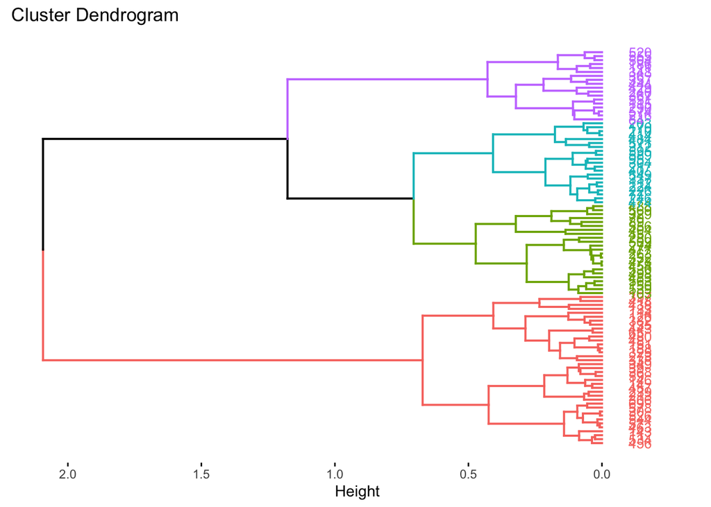

```r
# Visualize
fviz_dend(res.agnes, cex = 0.7, horiz = T)
```

El eje ‘Height’ nos muestra el “costo” de conglomerar.

## Comparando

Veamos qué tanto se parece a la clasificación jerarquica a la de partición:

```r
# verificar recodificacion
table(dataClus$clustPT,dataClus$clustAG,dnn = c('Particion','Aglomeracion'))
```

```
##          Aglomeracion
## Particion  1  2  3  4
##         1  4  0  0 19
##         2  0  5 17  0
##         3  0  1  0 18
##         4 17 17  1  1
```

## Estrategia Divisiva

Esta estrategia comienza con todos los casos como un gran cluster; para de ahi dividir en clusters más pequeños. Comparando con el proceso anterior, el paso 1 no es necesario repetirlo, por lo que vamos directo al paso 2:

### 2. Calcular clusters

La función **hcut** es la que usaremos para el método jerarquico, y el algoritmo divisivo se emplea usando **diana**:

```r
set.seed(123)
res.diana <- hcut(g.dist, k = 4,hc_func='diana')
dataClus$clustDIV=res.diana$cluster
```

### 3. Explorar Resultados

```r
library(plyr) # para funcion "each"..

# nota el uso de as.matrix con cbind:
aggregate(cbind(RDG,MATH,CIV)~ clustDIV, data=dataClus,mean)
```

```
##   clustDIV      RDG     MATH      CIV
## 1        1 43.37907 43.79302 50.44651
## 2        2 55.58387 54.06129 55.71613
## 3        3 65.44118 64.78824 61.12353
## 4        4 45.37778 42.93333 32.03333
```

¿Hay que recodificar la etiqueta del cluster?

```r
# adaptar de ser necesario!!!
dataClus$clustDIV=dplyr::recode(dataClus$clustDIV, `1` = 4, `2`=2,`3`=3,`4`=1)
```

### 4. Visualizar

El **dendograma** nos muestra el proceso de conglomeración:

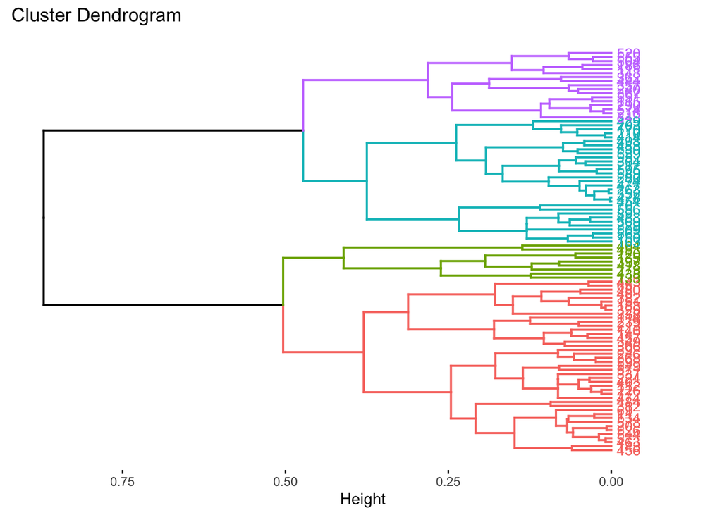

```r
# Visualize
fviz_dend(res.diana, cex = 0.7, horiz = T)
```

El eje ‘Height’ nos muestra el “costo” de conglomerar.

## Comparando

Veamos qué tanto se parece ambas la clasificaciones jerárquicas:

```r
# verificar recodificacion
table(dataClus$clustDIV,dataClus$clustAG,dnn = c('Division','Aglomeracion'))
```

```
##         Aglomeracion
## Division  1  2  3  4
##        1  0  2  0  7
##        2  9 21  1  0
##        3  0  0 17  0
##        4 12  0  0 31
```

Nota que en estas técnicas (partición y jerarquica) todo elemento termina siendo parte de un cluster.

# Estrategia Basada en Densidad

La estrategia basada en densidad sigue una estrategia muy sencilla: juntar a los casos cuya cercanía entre sí los diferencia de otros.

#### Mapa de casos

Sin embargo, el principal problema es que necesitamos un **mapa de posiciones** para todos los casos. Eso requiere una técnica que *proyecte* las dimensiones originales en un plano *bidimensional*. Para ello usaremos la técnica llamada **escalamiento multidimensional**:

```r
proyeccion = cmdscale(g.dist, k=2,add = T) # k is the number of dim
```

Habiendo calculado la proyeccción, recuperemos las coordenadas del mapa del mundo basado en nuestras dimensiones nuevas:

```r
# data frame prep:
dataClus$dim1 <- proyeccion$points[,1]
dataClus$dim2 <- proyeccion$points[,2]
```

Aquí puedes ver el mapa:

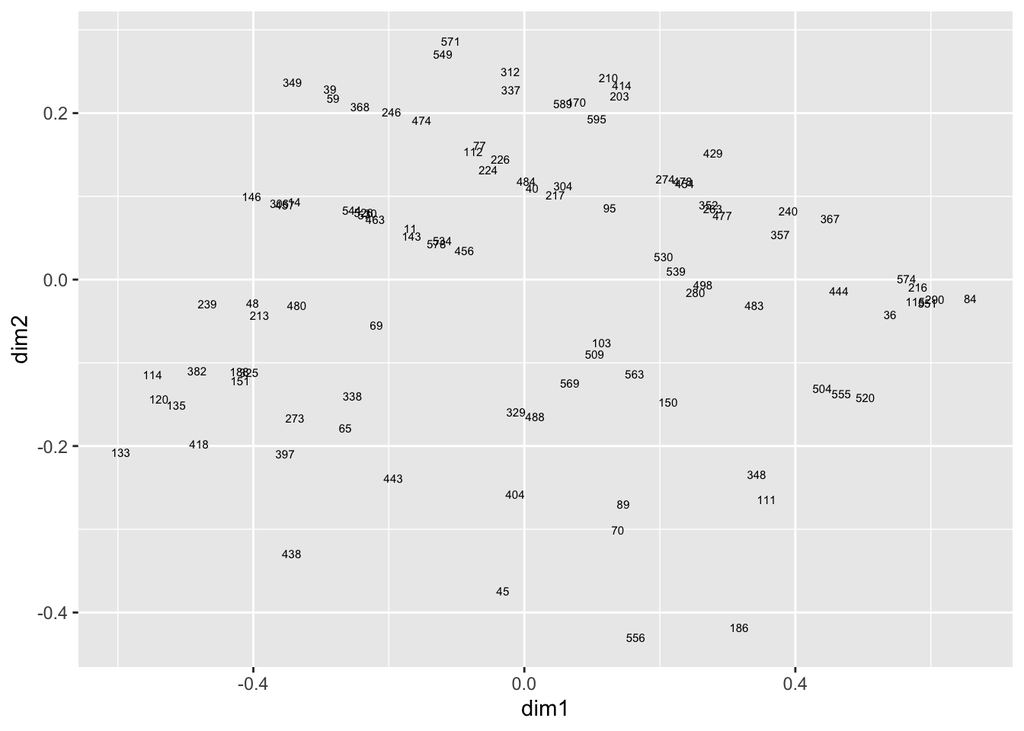

```r
base= ggplot(dataClus,aes(x=dim1, y=dim2,label=row.names(dataClus)))
base + geom_text(size=2)
```

Coloreemos el mapa anterior segun el cluster al que corresponden.

Procedeamos a gráficar:

- PAM

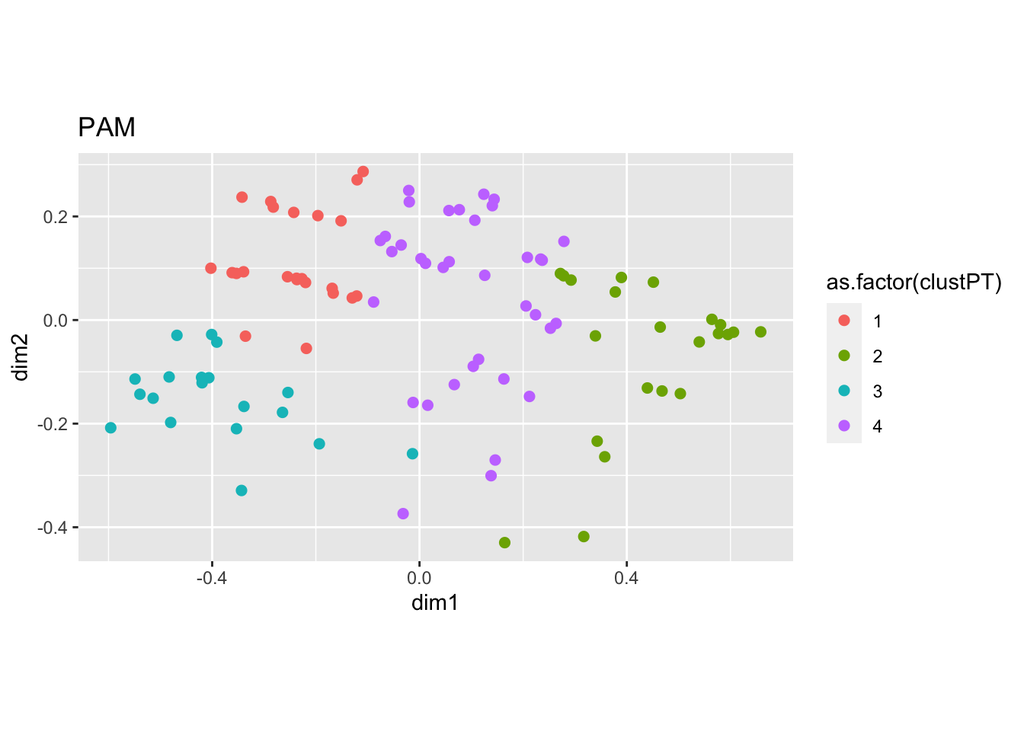

```r
base= ggplot(dataClus,aes(x=dim1, y=dim2)) +  coord_fixed()
base + geom_point(size=2, aes(color=as.factor(clustPT)))  + labs(title = "PAM")
```

- AGNES

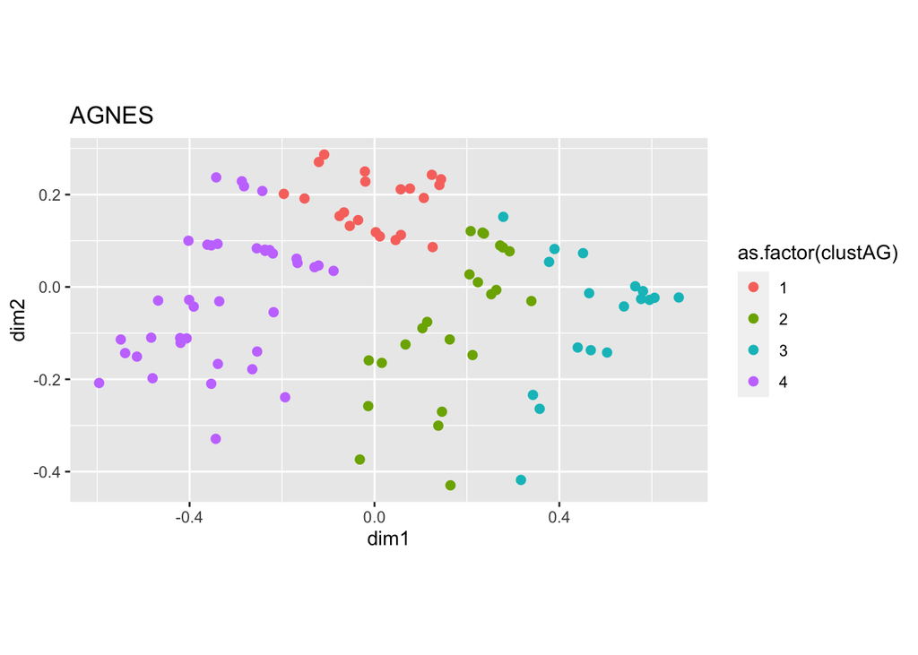

```r
base + geom_point(size=2, aes(color=as.factor(clustAG))) + labs(title = "AGNES")
```

- DIANA

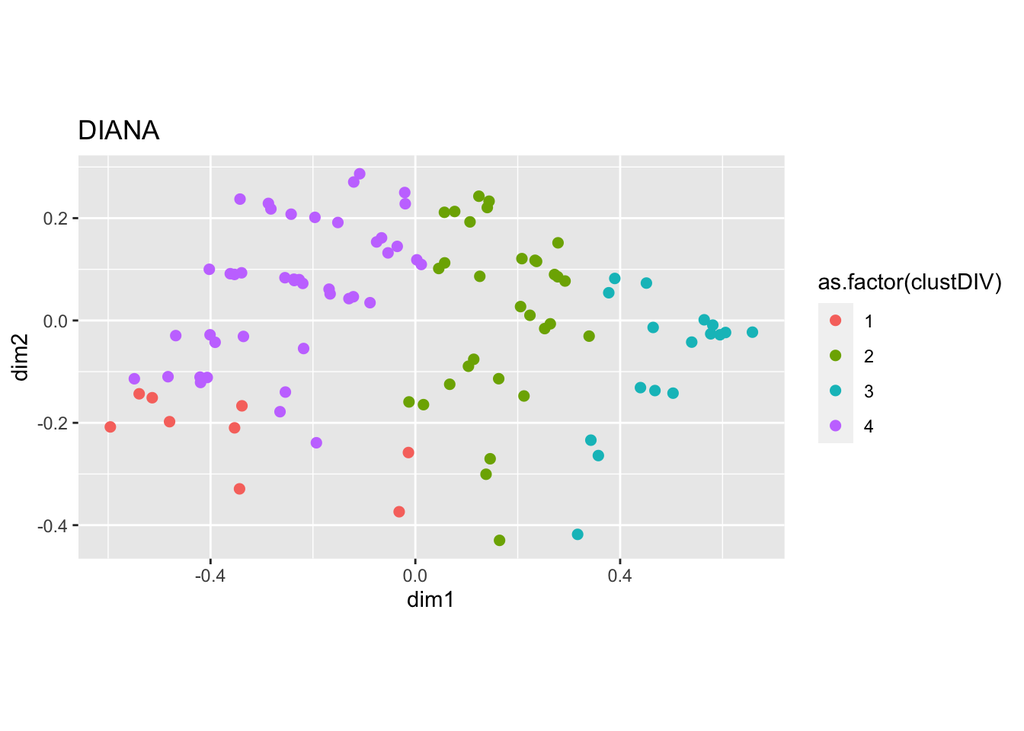

```r
base + geom_point(size=2, aes(color=as.factor(clustDIV))) + labs(title = "DIANA")
```

Ahora **calculemos** usando **dbscan**:

1. Nuevas distancias: Las posiciones son la información para dbscan.

```r
# euclidea!!
g.dist.cmd = daisy(dataClus[,c('dim1','dim2')], metric = 'euclidean')
```

2. Calculo de epsilon

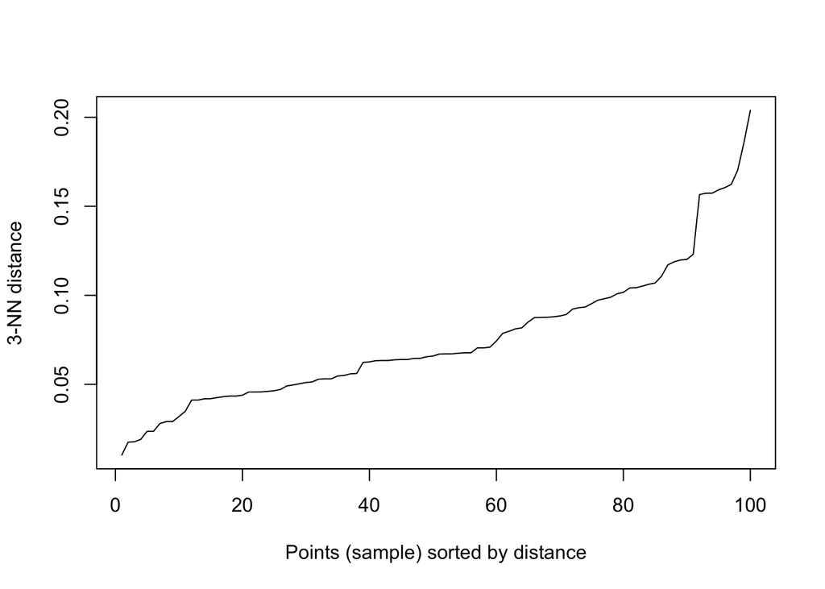

```r
library(dbscan)
kNNdistplot(g.dist.cmd, k=3)
```

3. Obteniendo clusters

```r
library(fpc)
db.cmd = fpc::dbscan(g.dist.cmd, eps=0.06, MinPts=10,method = 'dist')
```

De lo anterior podemos saber:

```r
db.cmd
```

```
## dbscan Pts=100 MinPts=10 eps=0.06
##
##   0
## 100
```

Pongamos esos valores en otra columna:

```r
dataClus$dbCMD=as.factor(db.cmd$cluster)
```

4. Graficando

Aquí sin texto:

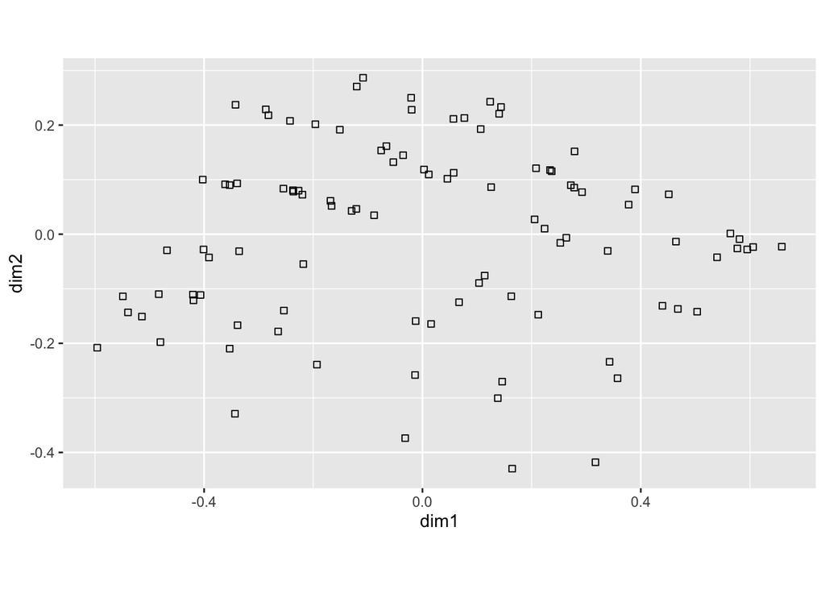

```r
library(ggrepel)
base= ggplot(dataClus[dataClus$dbCMD!=0,],aes(x=dim1, y=dim2)) + coord_fixed()
dbplot= base + geom_point(aes(color=dbCMD))
dbplot + geom_point(data=dataClus[dataClus$dbCMD==0,],shape=0)
```

Nota que en esta técnica hay casos que no serán clusterizados.